# tidy_tuesday_spotify

# Models

## Model for popularity predicted by genres

```r
popularity_1 <- lm(track_popularity ~ playlist_genre,
                   data = spotify)

summary(popularity_1)
```

```
##
## Call:
## lm(formula = track_popularity ~ playlist_genre, data = spotify)
##
## Residuals:
##     Min      1Q  Median      3Q     Max
## -47.745 -17.728   3.166  18.973  64.166
##
## Coefficients:
##                     Estimate Std. Error t value Pr(>|t|)
## (Intercept)          34.8335     0.3165  110.07   <2e-16 ***
## playlist_genrelatin  12.1930     0.4664   26.14   <2e-16 ***
## playlist_genrepop    12.9113     0.4583   28.17   <2e-16 ***
## playlist_genrer&b     6.3900     0.4600   13.89   <2e-16 ***
## playlist_genrerap     8.3819     0.4533   18.49   <2e-16 ***
## playlist_genrerock    6.8948     0.4716   14.62   <2e-16 ***
## ---
## Signif. codes:  0 '***' 0.001 '**' 0.01 '*' 0.05 '.' 0.1 ' ' 1
##
## Residual standard error: 24.6 on 32827 degrees of freedom
## Multiple R-squared:  0.0306, Adjusted R-squared:  0.03045
## F-statistic: 207.2 on 5 and 32827 DF,  p-value: < 2.2e-16
```

```r
# Genre seems to be a significant predictor of popularity, however, according to the adjuster R-squared value, this model explains only 3% of the variance of our data.
```

## Model for popularity predicted by danceability

```r
# Checking dancebility scores (all scores should be on a 0-1 scale)
spotify %>%
  count(danceability) # %>% View()
```

```
## # A tibble: 822 × 2
##    danceability     n
##           <dbl> <int>
##  1       0          1
##  2       0.0771     1
##  3       0.0787     1
##  4       0.0985     1
##  5       0.116      1
##  6       0.118      1
##  7       0.13       1
##  8       0.135      2
##  9       0.14       2
## 10       0.141      1
## # ℹ 812 more rows
```

```r
# Checking energy scores
# Checking track duration variable
```

```r
popularity_2 <- lm(track_popularity ~ playlist_genre + danceability + energy + duration_ms,
                       data = spotify)

summary(popularity_2)
```

```
##
## Call:
## lm(formula = track_popularity ~ playlist_genre + danceability +
##     energy + duration_ms, data = spotify)
##
## Residuals:
##     Min      1Q  Median      3Q     Max
## -62.817 -17.783   2.888  18.941  63.265
##
## Coefficients:
##                       Estimate Std. Error t value Pr(>|t|)
## (Intercept)          5.105e+01  1.121e+00  45.550   <2e-16 ***
## playlist_genrelatin  1.015e+01  4.692e-01  21.627   <2e-16 ***
## playlist_genrepop    1.154e+01  4.593e-01  25.129   <2e-16 ***
## playlist_genrer&b    4.489e+00  4.851e-01   9.254   <2e-16 ***
## playlist_genrerap    5.424e+00  4.669e-01  11.619   <2e-16 ***
## playlist_genrerock   8.809e+00  4.918e-01  17.911   <2e-16 ***
## danceability         9.635e+00  1.027e+00   9.382   <2e-16 ***
## energy              -1.234e+01  7.970e-01 -15.479   <2e-16 ***
## duration_ms         -5.676e-05  2.286e-06 -24.830   <2e-16 ***
## ---
## Signif. codes:  0 '***' 0.001 '**' 0.01 '*' 0.05 '.' 0.1 ' ' 1
##
## Residual standard error: 24.24 on 32824 degrees of freedom
## Multiple R-squared:  0.05889,    Adjusted R-squared:  0.05866
## F-statistic: 256.7 on 8 and 32824 DF,  p-value: < 2.2e-16
```

```r
# Genre, danceability, energy, and the duration of the tracks are significant predictors of popularity. Including more variables in the model led to an increased adjusted R-squared value of 5.8%, thus greater explained variance.
```

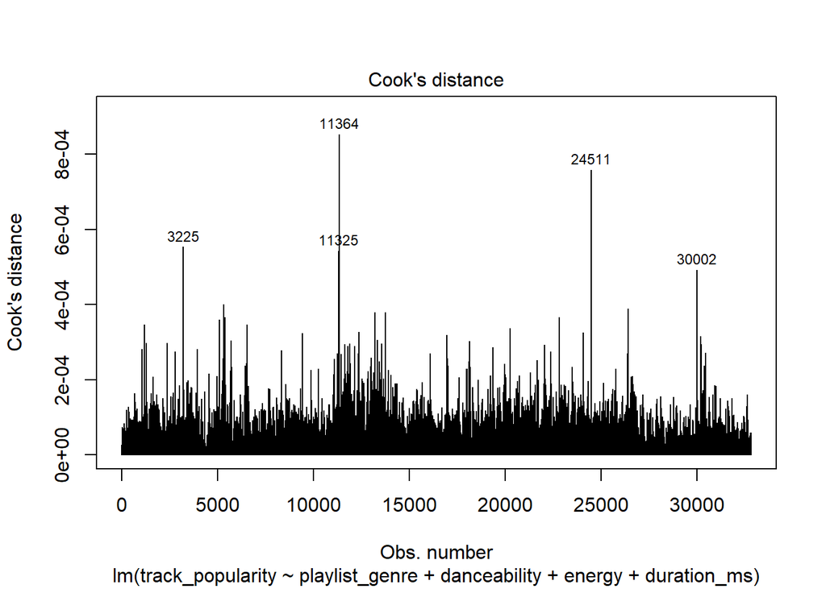

```r
# Plotting Cook's distance for the model, observing the 5 most influential outliers (Cook's distance > 0.5)
plot(popularity_2, which = 4, id.n = 5)
```

```r
# No influential outliers found
```

## Assumption check

Normality assumption check

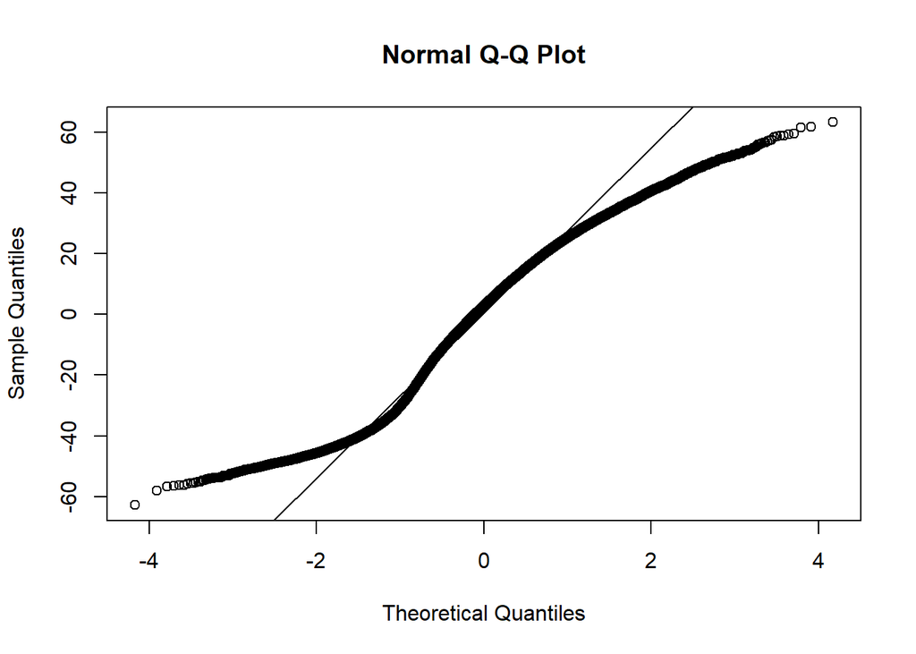

```r
# Residuals
residuals <- residuals(popularity_2)

# Q-Q plot
qqnorm(residuals)
qqline(residuals)
```

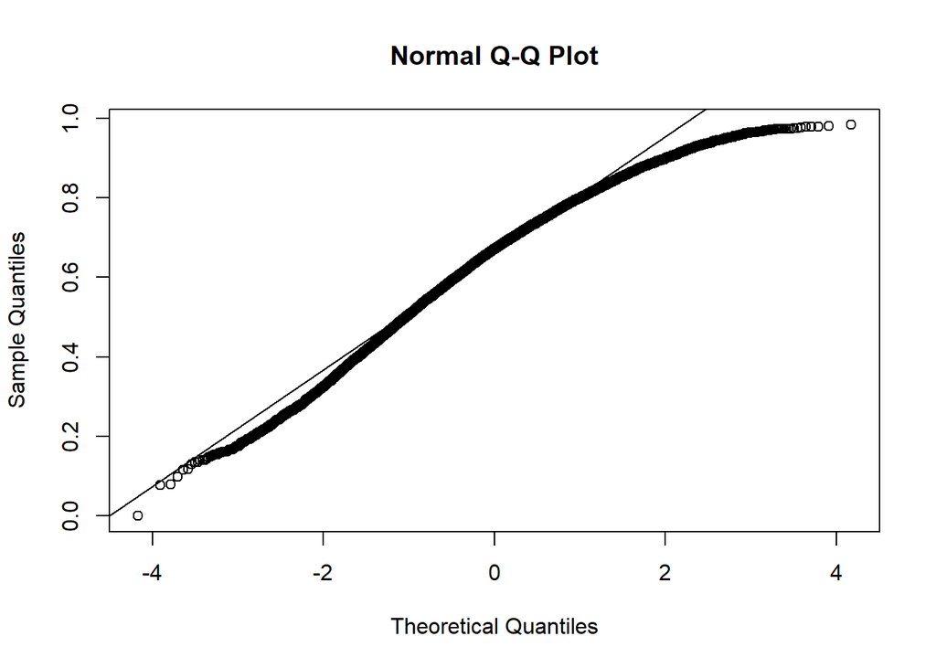

```r
qqnorm(spotify$danceability)
qqline(spotify$danceability)
```

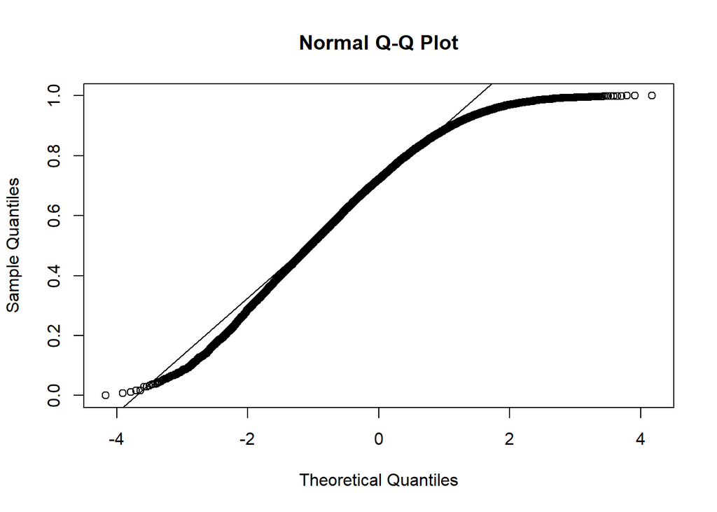

```r
qqnorm(spotify$energy)
qqline(spotify$energy)
```

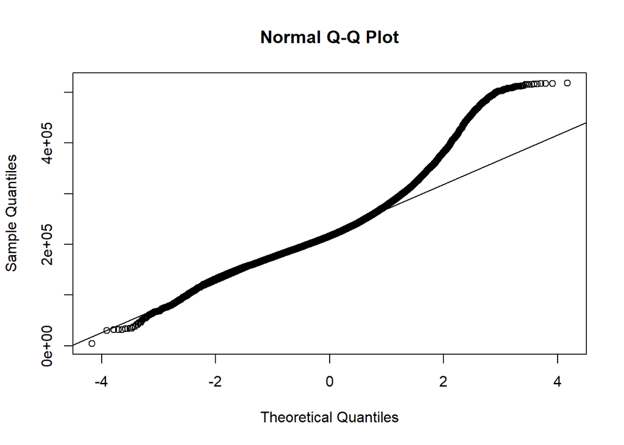

```r
qqnorm(spotify$duration_ms)
qqline(spotify$duration_ms)
```

```r
# Based on the Q-Q plot, the normality assumption is slightly violated. Checking the normality of danceability, energy, and duration predictors, we can see that the two latter are not normally distributed, so we might consider transforming these data.
```

Linearity assumption check

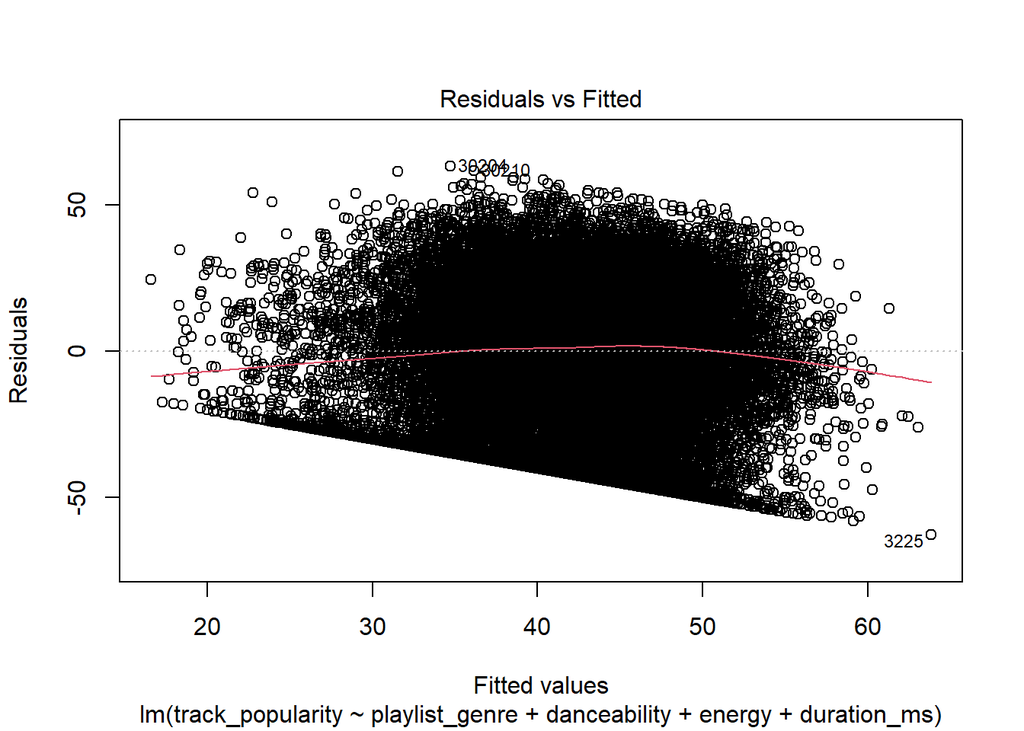

```r
plot(x = popularity_2, which = 1)
```

Homoscedasticty assumption check

```r
bptest(popularity_2)
```

```
##
##  studentized Breusch-Pagan test
##
## data:  popularity_2
## BP = 299.1, df = 8, p-value < 2.2e-16
```

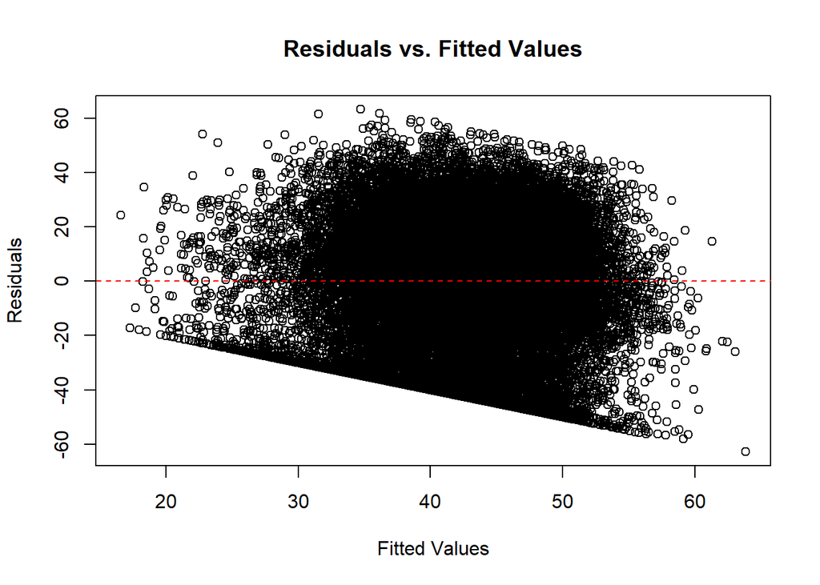

```r
residuals <- residuals(popularity_2)
fitted_values <- fitted(popularity_2)

# Create a scatterplot of residuals vs. fitted values
plot(fitted_values, residuals, xlab = "Fitted Values", ylab = "Residuals",
     main = "Residuals vs. Fitted Values")
abline(h = 0, col = "red", lty = 2)  # Add a horizontal line at y = 0 for reference
```

```r
# Based on the test, the homoscedasticity assumption is violated
```

Multicollinearity assumption check

```r
vif_values <- vif(popularity_2)

print(vif_values)
```

```
##                    GVIF Df GVIF^(1/(2*Df))
## playlist_genre 1.476577  5        1.039742
## danceability   1.240425  1        1.113744
## energy         1.161518  1        1.077738
## duration_ms    1.045106  1        1.022304
```

Given that both the normality and the homoscedasticity assumptions are violated, we need to apply some transformation to our data. Based on the normality check of our predictors, I will transform the energy and the duration data.u

# SQUARE ROOT TRANSFORMATION

```r
spotify <- spotify %>%
  mutate(energy_sqrt = sqrt(energy)) %>%
  mutate(duration_sqrt = sqrt(duration_ms))
```

Building the new model with square-root transformed data

```r
popularity_sqrt <- lm(track_popularity ~ playlist_genre + danceability + energy_sqrt + duration_sqrt,
                       data = spotify)

summary(popularity_sqrt)
```

```
##
## Call:
## lm(formula = track_popularity ~ playlist_genre + danceability +
##     energy_sqrt + duration_sqrt, data = spotify)
##
## Residuals:
##     Min      1Q  Median      3Q     Max
## -65.313 -17.827   2.911  19.003  63.659
##
## Coefficients:
##                       Estimate Std. Error t value Pr(>|t|)
## (Intercept)          67.667153   1.667861  40.571   <2e-16 ***
## playlist_genrelatin  10.473899   0.469006  22.332   <2e-16 ***
## playlist_genrepop    11.905249   0.458880  25.944   <2e-16 ***
## playlist_genrer&b     4.918030   0.484382  10.153   <2e-16 ***
## playlist_genrerap     5.730533   0.466002  12.297   <2e-16 ***
## playlist_genrerock    8.952658   0.492598  18.174   <2e-16 ***
## danceability         10.045746   1.027941   9.773   <2e-16 ***
## energy_sqrt         -16.628105   1.214290 -13.694   <2e-16 ***
## duration_sqrt        -0.052662   0.002251 -23.400   <2e-16 ***
## ---
## Signif. codes:  0 '***' 0.001 '**' 0.01 '*' 0.05 '.' 0.1 ' ' 1
##
## Residual standard error: 24.28 on 32824 degrees of freedom
## Multiple R-squared:  0.05595,    Adjusted R-squared:  0.05572
## F-statistic: 243.2 on 8 and 32824 DF,  p-value: < 2.2e-16
```

## Assumption check round 2

Normality assumption check

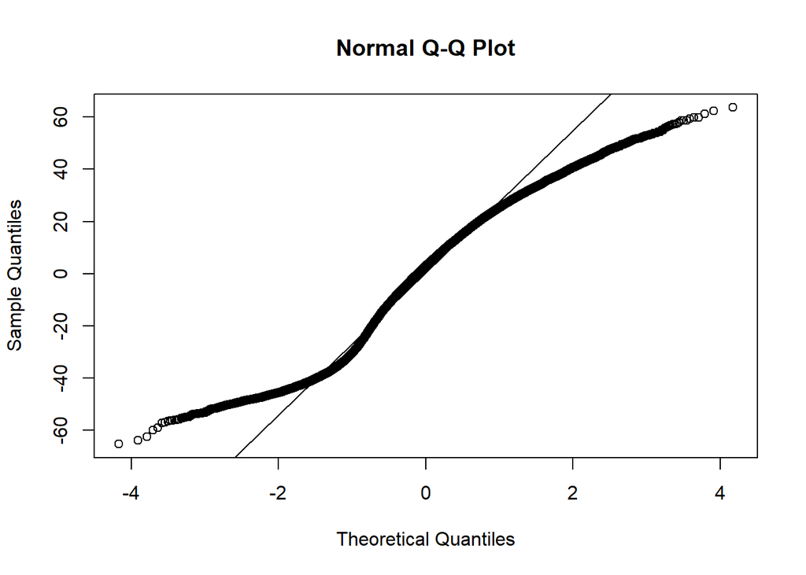

```r
# Residuals
residuals_sqrt <- residuals(popularity_sqrt)

# Q-Q plot
qqnorm(residuals_sqrt)
qqline(residuals_sqrt)
```

```r
# Based on the Q-Q plot, the normality assumption is slightly violated
```

Linearity assumption check

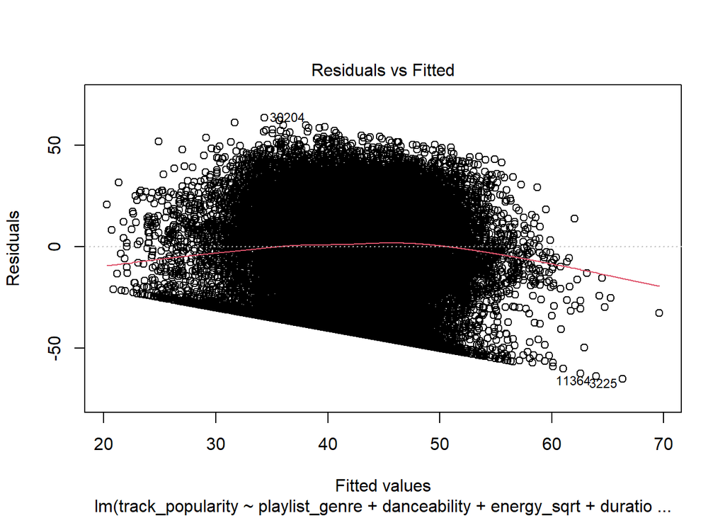

```r
plot(x = popularity_sqrt, which = 1)
```

Homoscedasticty assumption cherck

```r
bptest(popularity_sqrt)
```

```
##
##  studentized Breusch-Pagan test
##
## data:  popularity_sqrt
## BP = 287.22, df = 8, p-value < 2.2e-16
```

```r
# Based on the test, the homoscedasticity assumption is still violated
```

Multicollinearity assumption check

```r
vif_values_sqrt <- vif(popularity_sqrt)

print(vif_values_sqrt)
```

```
##                    GVIF Df GVIF^(1/(2*Df))
## playlist_genre 1.465092  5        1.038930
## danceability   1.238946  1        1.113080
## energy_sqrt    1.147934  1        1.071417
## duration_sqrt  1.048424  1        1.023926
```

# LOGARITHMIC TRANSFORMATION

Given that both the normality and the homoscedasticity assumptions are still violated after the square root transformation, I’ll try logarithmic transformation.

```r
spotify <- spotify %>%
  mutate(energy_log = log(energy)) %>%
  mutate(duration_log = log(duration_ms))
```

Building the new model with logarithmic transformed data

```r
popularity_log <- lm(track_popularity ~ playlist_genre + danceability + energy_log + duration_log,
                       data = spotify)

summary(popularity_sqrt)
```

```
##
## Call:
## lm(formula = track_popularity ~ playlist_genre + danceability +
##     energy_sqrt + duration_sqrt, data = spotify)
##
## Residuals:
##     Min      1Q  Median      3Q     Max
## -65.313 -17.827   2.911  19.003  63.659
##
## Coefficients:
##                       Estimate Std. Error t value Pr(>|t|)
## (Intercept)          67.667153   1.667861  40.571   <2e-16 ***
## playlist_genrelatin  10.473899   0.469006  22.332   <2e-16 ***
## playlist_genrepop    11.905249   0.458880  25.944   <2e-16 ***
## playlist_genrer&b     4.918030   0.484382  10.153   <2e-16 ***
## playlist_genrerap     5.730533   0.466002  12.297   <2e-16 ***
## playlist_genrerock    8.952658   0.492598  18.174   <2e-16 ***
## danceability         10.045746   1.027941   9.773   <2e-16 ***
## energy_sqrt         -16.628105   1.214290 -13.694   <2e-16 ***
## duration_sqrt        -0.052662   0.002251 -23.400   <2e-16 ***
## ---
## Signif. codes:  0 '***' 0.001 '**' 0.01 '*' 0.05 '.' 0.1 ' ' 1
##
## Residual standard error: 24.28 on 32824 degrees of freedom
## Multiple R-squared:  0.05595,    Adjusted R-squared:  0.05572
## F-statistic: 243.2 on 8 and 32824 DF,  p-value: < 2.2e-16
```

## Assumption check round 3

Normality assumption check

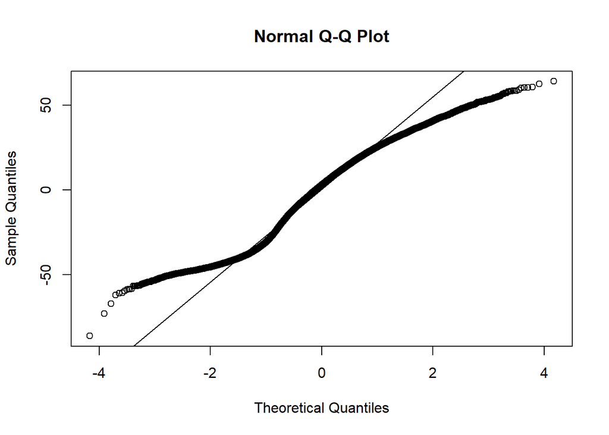

```r
# Residuals
residuals_log <- residuals(popularity_log)

# Q-Q plot
qqnorm(residuals_log)
qqline(residuals_log)
```

```r
# Based on the Q-Q plot, the normality assumption is slightly violated
```

Linearity assumption check

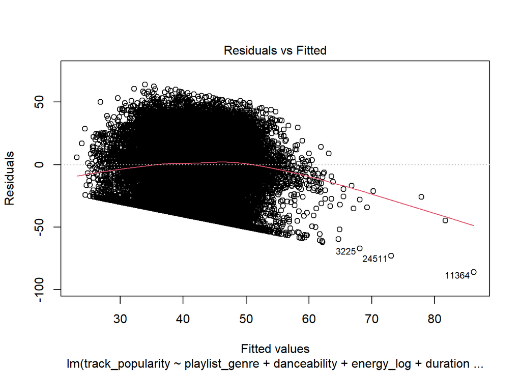

```r
plot(x = popularity_log, which = 1)
```

```r
# Linearity got worse after the log transformation
```

Homoscedasticty assumption cherck

```r
bptest(popularity_log)
```

```
##
##  studentized Breusch-Pagan test
##
## data:  popularity_log
## BP = 266.08, df = 8, p-value < 2.2e-16
```

```r
# Based on the test, the homoscedasticity assumption is still violated
```

Multicollinearity assumption check

```r
vif_values_log <- vif(popularity_log)

print(vif_values_log)
```

```
##                    GVIF Df GVIF^(1/(2*Df))
## playlist_genre 1.438906  5        1.037058
## danceability   1.238841  1        1.113032
## energy_log     1.127404  1        1.061793
## duration_log   1.052656  1        1.025990
```

Some assumptions of our models are violated, even after square root or logarithmic data transformation. Due to this, for the comparison of the simple and the more complex model, I will use the original complex model that contains non-transformed data. However, we need to take the assumption violations into consideration when interpreting the results.

# Model comparison

Model test statistics for the simple model

```r
summary(popularity_1)
```

```
##
## Call:
## lm(formula = track_popularity ~ playlist_genre, data = spotify)
##
## Residuals:
##     Min      1Q  Median      3Q     Max
## -47.745 -17.728   3.166  18.973  64.166
##
## Coefficients:
##                     Estimate Std. Error t value Pr(>|t|)
## (Intercept)          34.8335     0.3165  110.07   <2e-16 ***
## playlist_genrelatin  12.1930     0.4664   26.14   <2e-16 ***
## playlist_genrepop    12.9113     0.4583   28.17   <2e-16 ***
## playlist_genrer&b     6.3900     0.4600   13.89   <2e-16 ***
## playlist_genrerap     8.3819     0.4533   18.49   <2e-16 ***
## playlist_genrerock    6.8948     0.4716   14.62   <2e-16 ***
## ---
## Signif. codes:  0 '***' 0.001 '**' 0.01 '*' 0.05 '.' 0.1 ' ' 1
##
## Residual standard error: 24.6 on 32827 degrees of freedom
## Multiple R-squared:  0.0306, Adjusted R-squared:  0.03045
## F-statistic: 207.2 on 5 and 32827 DF,  p-value: < 2.2e-16
```

```r
augment(popularity_1)
```

```
## # A tibble: 32,833 × 8
##    track_popularity playlist_genre .fitted .resid     .hat .sigma    .cooksd
##               <dbl> <chr>            <dbl>  <dbl>    <dbl>  <dbl>      <dbl>
##  1               66 pop               47.7   18.3 0.000182   24.6 0.0000167
##  2               67 pop               47.7   19.3 0.000182   24.6 0.0000185
##  3               70 pop               47.7   22.3 0.000182   24.6 0.0000248
##  4               60 pop               47.7   12.3 0.000182   24.6 0.00000751
##  5               69 pop               47.7   21.3 0.000182   24.6 0.0000226
##  6               67 pop               47.7   19.3 0.000182   24.6 0.0000185
##  7               62 pop               47.7   14.3 0.000182   24.6 0.0000102
##  8               69 pop               47.7   21.3 0.000182   24.6 0.0000226
##  9               68 pop               47.7   20.3 0.000182   24.6 0.0000205
## 10               67 pop               47.7   19.3 0.000182   24.6 0.0000185
## # ℹ 32,823 more rows
## # ℹ 1 more variable: .std.resid <dbl>
```

```r
# Get model test statistics
simple_model_summary <- summary(popularity_1)
simple_adj_r2 <- simple_model_summary$adj.r.squared
simple_f <- simple_model_summary$fstatistic[1]
simple_f_df1 <- simple_model_summary$fstatistic[2]
simple_f_df2 <- simple_model_summary$fstatistic[3]
simple_p <- pf(simple_f, simple_f_df1, simple_f_df2, lower.tail = FALSE)

# Display model test statistics
cat(paste("Adjusted R2:", simple_adj_r2, "\n"))
```

```
## Adjusted R2: 0.0304475054835022
```

```r
cat(paste("F-statistic:", simple_f, "\n"))
```

```
## F-statistic: 207.209051224783
```

```r
cat(paste("Degrees of freedom (DF):", simple_f_df1, ",", simple_f_df2, "\n"))
```

```
## Degrees of freedom (DF): 5 , 32827
```

```r
cat(paste("P-value:", simple_p, "\n"))
```

```
## P-value: 2.70265717034187e-218
```

Model test statistics for the complex model

```r
summary(popularity_2)
```

```
##
## Call:
## lm(formula = track_popularity ~ playlist_genre + danceability +
##     energy + duration_ms, data = spotify)
##
## Residuals:
##     Min      1Q  Median      3Q     Max
## -62.817 -17.783   2.888  18.941  63.265
##
## Coefficients:
##                       Estimate Std. Error t value Pr(>|t|)
## (Intercept)          5.105e+01  1.121e+00  45.550   <2e-16 ***
## playlist_genrelatin  1.015e+01  4.692e-01  21.627   <2e-16 ***
## playlist_genrepop    1.154e+01  4.593e-01  25.129   <2e-16 ***
## playlist_genrer&b    4.489e+00  4.851e-01   9.254   <2e-16 ***
## playlist_genrerap    5.424e+00  4.669e-01  11.619   <2e-16 ***
## playlist_genrerock   8.809e+00  4.918e-01  17.911   <2e-16 ***
## danceability         9.635e+00  1.027e+00   9.382   <2e-16 ***
## energy              -1.234e+01  7.970e-01 -15.479   <2e-16 ***
## duration_ms         -5.676e-05  2.286e-06 -24.830   <2e-16 ***
## ---
## Signif. codes:  0 '***' 0.001 '**' 0.01 '*' 0.05 '.' 0.1 ' ' 1
##
## Residual standard error: 24.24 on 32824 degrees of freedom
## Multiple R-squared:  0.05889,    Adjusted R-squared:  0.05866
## F-statistic: 256.7 on 8 and 32824 DF,  p-value: < 2.2e-16
```

```r
augment(popularity_2)
```

```
## # A tibble: 32,833 × 11
##    track_popularity playlist_genre danceability energy duration_ms .fitted
##               <dbl> <chr>                 <dbl>  <dbl>       <dbl>   <dbl>
##  1               66 pop                   0.748  0.916      194754    47.4
##  2               67 pop                   0.726  0.815      162600    50.3
##  3               70 pop                   0.675  0.931      176616    47.6
##  4               60 pop                   0.718  0.93       169093    48.4
##  5               69 pop                   0.65   0.833      189052    47.8
##  6               67 pop                   0.675  0.919      163049    48.5
##  7               62 pop                   0.449  0.856      187675    45.7
##  8               69 pop                   0.542  0.903      207619    44.9
##  9               68 pop                   0.594  0.935      193187    45.8
## 10               67 pop                   0.642  0.818      253040    44.3
## # ℹ 32,823 more rows
## # ℹ 5 more variables: .resid <dbl>, .hat <dbl>, .sigma <dbl>, .cooksd <dbl>,
## #   .std.resid <dbl>
```

```r
# Get model test statistics
complex_model_summary <- summary(popularity_2)
complex_adj_r2 <- complex_model_summary$adj.r.squared
complex_f <- complex_model_summary$fstatistic[1]
complex_f_df1 <- complex_model_summary$fstatistic[2]
complex_f_df2 <- complex_model_summary$fstatistic[3]
complex_p <- pf(complex_f, complex_f_df1, complex_f_df2, lower.tail = FALSE)

# Display model test statistics
cat(paste("Adjusted R2:", complex_adj_r2, "\n"))
```

```
## Adjusted R2: 0.0586568292293228
```

```r
cat(paste("F-statistic:", complex_f, "\n"))
```

```
## F-statistic: 256.727809614911
```

```r
cat(paste("Degrees of freedom (DF):", complex_f_df1, ",", complex_f_df2, "\n"))
```

```
## Degrees of freedom (DF): 8 , 32824
```

```r
cat(paste("P-value:", complex_p, "\n"))
```

```
## P-value: 0
```

```r
# Coefficients information
tab_model(popularity_2)
```

|  | track_popularity |  |  |
| --- | --- | --- | --- |
| Predictors | Estimates | CI | p |
| (Intercept) | 51.05 | 48.85 – 53.25 | **<0.001** |
| playlist genre [latin] | 10.15 | 9.23 – 11.07 | **<0.001** |
| playlist genre [pop] | 11.54 | 10.64 – 12.44 | **<0.001** |
| playlist genre [r&b] | 4.49 | 3.54 – 5.44 | **<0.001** |
| playlist genre [rap] | 5.42 | 4.51 – 6.34 | **<0.001** |
| playlist genre [rock] | 8.81 | 7.85 – 9.77 | **<0.001** |
| danceability | 9.64 | 7.62 – 11.65 | **<0.001** |
| energy | -12.34 | -13.90 – -10.77 | **<0.001** |
| duration ms | -0.00 | -0.00 – -0.00 | **<0.001** |
| Observations | 32833 |  |  |
| R<sup>2</sup> / R<sup>2</sup> adjusted | 0.059 / 0.059 |  |  |

Comparison

```r
# Comparing the two models
compare <- anova(popularity_1, popularity_2)

# Extracting F and p values
compare_f <- compare$F[2]
compare_p <- compare$Pr[2]

# Displaying F and p values
cat(paste("F-test statistic:", compare_f, "\n"))
```

```
## F-test statistic: 328.909983435661
```

```r
cat(paste("p-value:", compare_p, "\n"))
```

```
## p-value: 1.9266149075028e-210
```

```r
# Looking at the two models and their AIC values
glance(popularity_1) %>%
  rbind(glance(popularity_2)) %>%
  as.data.frame()
```

```
##    r.squared adj.r.squared    sigma statistic       p.value df    logLik
## 1 0.03059516    0.03044751 24.60078  207.2091 2.702657e-218  5 -151741.8
## 2 0.05888620    0.05865683 24.24026  256.7278  0.000000e+00  8 -151255.6
##        AIC      BIC deviance df.residual  nobs
## 1 303497.7 303556.4 19866852       32827 32833
## 2 302531.2 302615.2 19287059       32824 32833
```

```r
# The two models differ significantly, and as the AIC of the complex model (302531.2) is lower than the AIC of the simpler model (303497.7), the complex model is considered better.
```

# Discussion

In this analysis, I have observed some parameters of Spotify tracks, such as their genre, danceability, energy, speechiness, valence, and duration. I was interested in how these variables are related to the popularity of the tracks. I have built models to see how these variables can predict popularity. One of my models contained only the genre of the music, while in a more complex model, danceability, energy, and duration predictors were also included. Based on the comparison of the two models, the more complex one seemed to be significantly better than the simple one. However, there are a few things that are important to notice. First, the normality and the homoscedasticity assumptions of the complex model were not met, even after the transformation (square root, logarithmic) of the data. Second, the explanatory power of these models are quite low, the simple model explains only 3% of the variance, and for the complex model, this value is around 6%. This suggests that these models are fairly poor at predicting popularity.